# PS1

## Problem 1: Abalone Data

1. Import the data into a data.frame in R. Use the information in the “abalone.names” file to give appropriate column names. (Note: Downloading and unzipping the file can take place outside of your submitted document, but importing the file should be in the submission.)

```r
# rm(list=ls())
abalone_data <- read.csv("data/abalone/abalone.data", header = FALSE)

# set appropriate colnames according to abalone.names
colnames(abalone_data) <- c("Sex", "Length", "Diam", "Height", "Whole", "Shucked", "Viscera", "Shell", "Rings")
```

```r
head(abalone_data)
```

```
  Sex Length  Diam Height  Whole Shucked Viscera Shell Rings
1   M  0.455 0.365  0.095 0.5140  0.2245  0.1010 0.150    15
2   M  0.350 0.265  0.090 0.2255  0.0995  0.0485 0.070     7
3   F  0.530 0.420  0.135 0.6770  0.2565  0.1415 0.210     9
4   M  0.440 0.365  0.125 0.5160  0.2155  0.1140 0.155    10
5   I  0.330 0.255  0.080 0.2050  0.0895  0.0395 0.055     7
6   I  0.425 0.300  0.095 0.3515  0.1410  0.0775 0.120     8
```

2. The data contains information on three different sexes of abalone. Report the number of observations belonging to each sex.

```r
table(abalone_data$Sex)
```

```
   F    I    M
1307 1342 1528
```

There are 1307 female, 1342 infant, and 1528 male.

3. Use the data to answer the following questions:
1. Which weight has the highest correlation with rings?

```r
cor(abalone_data$Rings, abalone_data[5:8])
```

```
         Whole   Shucked   Viscera    Shell
[1,] 0.5403897 0.4208837 0.5038192 0.627574
```

Shell weight has the highest correlation with rings with a correlation coefficient of 0.627574.

2. For that weight, which sex has the highest correlation?

```r
sexes <- unique(abalone_data$Sex)
sapply(sexes, function(sex) {
  abalone_by_sex <- abalone_data[abalone_data$Sex == sex, ]
  cor(abalone_by_sex[["Shell"]], abalone_by_sex$Rings)
})
```

```
        M         F         I
0.5109967 0.4059070 0.7254357
```

Infants have the highest correlation between shell weight and rings with a value of 0.7254357.

3. What are the weights of the abalone with the most rings?

```r
most_rings_idx <- which.max(abalone_data$Rings)
abalone_data[most_rings_idx, 5:8]
```

```
     Whole Shucked Viscera Shell
481 1.8075  0.7055  0.3215 0.475
```

The abalone with the most rings has a whole weight of 1.81, shucked weight of 0.71, viscera weight of 0.32, and shell weight of 0.475.

4. What percentage of abalones have a viscera weight larger than their shell weight?

```r
mean(abalone_data$Viscera > abalone_data$Shell)
```

```
[1] 0.06511851
```

6.51% of abalones have a viscera weight larger than their shell weight

4. Create a table of correlations between weights and rings, within each sex. The columns should be the four weights, and the rows should be the sexes.

```r
weights <- c("Whole", "Shucked", "Viscera", "Shell")

sapply(weights, function(w) {
  sapply(sexes, function(sex) {
    abalone_by_sex <- abalone_data[abalone_data$Sex == sex, ]
    cor(abalone_by_sex[[w]], abalone_by_sex$Rings)
  })
})
```

```
      Whole    Shucked   Viscera     Shell
M 0.3721966 0.22239382 0.3209535 0.5109967
F 0.2667585 0.09484802 0.2116154 0.4059070
I 0.6963268 0.62024577 0.6732727 0.7254357
```

5. Carry out a series of t-tests to examine whether the number of rings differs across the three sexes. Present the R output and interpret the results.

First, I create a function that allows me to manually carry out Welch’s t-test.

```r
#' manual implementation of Welch's t-test
#'
#' @param sex1 a character
#' @param sex2 a character
#'
#' @returns a list of the p-value, t-stat, and df
#'
#' @examples
#' manual_t_test("M", "F")
#' manual_t_test("I", "F")
manual_t_test <- function(sex1, sex2) {
  rings1 <- abalone_data$Rings[abalone_data$Sex == sex1]
  rings2 <- abalone_data$Rings[abalone_data$Sex == sex2]

  var1 <- var(rings1)
  var2 <- var(rings2)

  n1 <- length(rings1)
  n2 <- length(rings2)

  t_stat <- abs((mean(rings1) - mean(rings2)) / (sqrt((var1/n1) + (var2/n2))))
  df <- ((var1/n1)+(var2/n2))^2 / ( (((var1/n1)^2)/(n1-1)) + (((var2/n2)^2)/(n2-1)))

  p_val <- 2 * pt(-t_stat, df)
  return(c("p-value" = signif(p_val, 4), "t-stat" = signif(t_stat, 4), "df" = signif(df, 4)))
}
```

Next, let’s carry out the Welch’s t-test. We’ll start with the difference between male and female.

```r
manual_t_test("M", "F")
```

```
  p-value    t-stat        df
2.514e-04 3.666e+00 2.742e+03
```

The p-value is very small, which indicates that there is a statistically significant difference in the number of rings between male and female abalone.

Next, between infant and female.

```r
manual_t_test("I", "F")
```

```
   p-value     t-stat         df
3.081e-164  2.948e+01  2.509e+03
```

The p-value is very small, which indicates a significant difference in the number of rings between infant and female abalone.

Lastly, between male and infant.

```r
manual_t_test("M", "I")
```

```
   p-value     t-stat         df
2.766e-145  2.722e+01  2.859e+03
```

Just to check my function, let’s test it against the t.test function provided in R between M and F.

```r
t.test(Rings ~ Sex, data = abalone_data, subset = Sex %in% c("M", "F"))
```

```
    Welch Two Sample t-test

data:  Rings by Sex
t = 3.6657, df = 2742.4, p-value = 0.0002514
alternative hypothesis: true difference in means between group F and group M is not equal to 0
95 percent confidence interval:
 0.1971045 0.6505082
sample estimates:
mean in group F mean in group M
        11.1293         10.7055
```

The p-value given here is 0.0002514, which is the same as the one given by my manual implementation.

## Problem 2 - Food Expenditure Data

1. Import the data into a data.frame in R. As with the abalone data, you may download the data outside of your submission, but importation should take place inside the problem set submission.

```r
food_data <- read.csv("data/food_expenditure.csv")
```

2. Clean up the variable names. Simplify them.

```r
# take a look at the column names
colnames(food_data)
```

```
 [1] "ID"
 [2] "What.is.your.age."
 [3] "How.many.individuals.live.in.your.household.for.which.you.are.responsible.for.food.expenditures..excluding.yourself.."
 [4] "What.state.do.you.live.in."
 [5] "What.currency.are.you.reporting.your.food.expenditures.in."
 [6] "What.was.your.total.food.expenditure.in.the.last.week."
 [7] "What.was.your.total.food.expenditures.at.grocery.stores.in.the.last.week."
 [8] "What.was.your.food.expenditure.while.dining.out.in.the.last.week."
 [9] "What.was.your.food.expenditure..miscellaneous..in.the.last.week."
[10] "How.many.times.did.you.dine.out.last.week."
[11] "Are.you.including.alcohol.in.your.food.expenditures."
[12] "What.food.assistance.programs..if.any..did.you.use.for.your.food.expenditures.last.week."
```

```r
# clean it up
colnames(food_data) <- c("ID", "Age", "Household", "State", "Currency",
                         "Expenditure_Total", "Expenditure_Grocery", "Expenditure_Dining", "Expenditure_Misc",
                         "Num_Dining", "Alcohol", "Assistance")
# display first few rows
head(food_data)
```

```
  ID Age Household State Currency Expenditure_Total Expenditure_Grocery
1  1  68         7    LA      USD            436.35              168.59
2  2  88         5    WA      USD                                452.10
3  3  82         3    MS      USD             279.1              301.66
4  4  73         8    AK      USD            -20.98              139.66
5  5  89         0    IN      USD            494.87                  NA
6  6  18         6    WI      EUR            276.32              394.44
  Expenditure_Dining Expenditure_Misc Num_Dining Alcohol  Assistance
1             140.71           109.77          4     Yes        None
2             192.94               NA          1 Unknown        SNAP
3             239.84           103.94          9     Yes        None
4              69.19            44.84          2 Unknown        None
5             191.72           172.31          3     Yes        None
6             283.20           114.06          6 Unknown Food Pantry
```

3. Restrict the data to those paying in US dollars (USD). Show that it worked by confirming the number of observations before and after restricting the data.

```r
nrow(food_data)
```

```
[1] 262
```

```r
food_usd <- food_data[food_data$Currency == "USD", ]
nrow(food_usd)
```

```
[1] 230
```

Before restricting the data, there were 262 rows. After restricting the data, it dropped to 230.

The questions after this relate to data cleaning.

4. The variable related to age. Firstly, let’s take a look at what the numerical summary shows.

```r
summary(food_usd$Age)
```

```
   Min. 1st Qu.  Median    Mean 3rd Qu.    Max.    NA's
   2.00   30.00   51.00   52.67   76.00  150.00       9
```

The minimum is 2, and the maximum is 150, both of which seem improbable. Furthermore, there are 9 NAs. Next, let’s take a look at the boxplot.

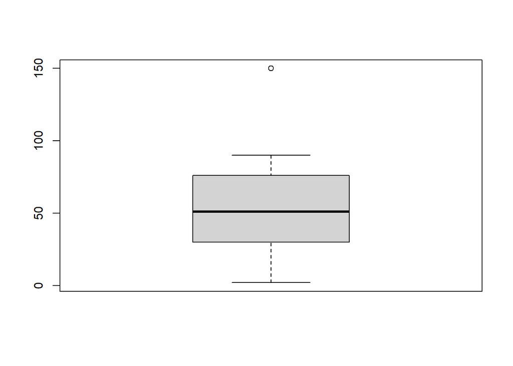

```r
boxplot(food_usd$Age)
```

From the boxplot, we can see that the entry of “150” is an outlier, so we can remove that. Furthermore, I will choose to limit the lower bound of the age to 16, which is when minors are typically able to start working, to my knowledge. I will also remove the NA values.

```r
food_updated <- food_usd[(food_usd$Age >= 16) & (food_usd$Age < 150) & !is.na(food_usd$Age), ]
summary(food_updated$Age)
```

```
   Min. 1st Qu.  Median    Mean 3rd Qu.    Max.
  16.00   33.00   54.00   54.17   76.00   90.00
```

Above is the updated numerical summary of the cleaned age data.

5. The variable related to state. First, I display the unique values in the state variable. I also sort it for easy viewing.

```r
sort(unique(food_updated$State))
```

```
 [1] ""   "AK" "AL" "AR" "AZ" "CA" "CO" "CT" "DC" "DE" "FL" "GA" "HI" "IA" "ID"
[16] "IL" "IN" "KS" "KY" "LA" "MA" "MD" "ME" "MI" "MN" "MO" "MS" "MT" "NC" "ND"
[31] "NE" "NH" "NJ" "NM" "NV" "NY" "OH" "OK" "OR" "PA" "PR" "RI" "SC" "SD" "TN"
[46] "TX" "UT" "VA" "VT" "WA" "WI" "WV" "WY" "XX"
```

From the above, we can see empty values ““, and made up states”XX”. Apparently, there is a list of official states available in R, so I will clean the data based on the states present in that list.

```r
food_updated <- food_updated[food_updated$State %in% state.abb, ]
sort(unique(food_updated$State))
```

```
 [1] "AK" "AL" "AR" "AZ" "CA" "CO" "CT" "DE" "FL" "GA" "HI" "IA" "ID" "IL" "IN"
[16] "KS" "KY" "LA" "MA" "MD" "ME" "MI" "MN" "MO" "MS" "MT" "NC" "ND" "NE" "NH"
[31] "NJ" "NM" "NV" "NY" "OH" "OK" "OR" "PA" "RI" "SC" "SD" "TN" "TX" "UT" "VA"
[46] "VT" "WA" "WI" "WV" "WY"
```

I’m going to trust that the R states are accurate because I do not actually know.

6. The four variables related to food expenditures. Let’s look at a numerical summary of the expenditures.

```r
expenditures <- c("Expenditure_Total", "Expenditure_Grocery", "Expenditure_Dining", "Expenditure_Misc")
summary(food_updated[expenditures])
```

```
 Expenditure_Total  Expenditure_Grocery Expenditure_Dining Expenditure_Misc
 Length:184         Min.   :-73.48      Min.   :  4.33     Min.   :-22.92
 Class :character   1st Qu.:140.44      1st Qu.: 59.54     1st Qu.: 34.12
 Mode  :character   Median :223.32      Median : 98.44     Median : 73.83
                    Mean   :236.09      Mean   :105.27     Mean   : 86.65
                    3rd Qu.:312.83      3rd Qu.:146.91     3rd Qu.:124.93
                    Max.   :658.51      Max.   :289.89     Max.   :316.47
                    NA's   :3           NA's   :4          NA's   :27
```

First, let’s take a look at the total expenditure to see why it was classified as character values.

```r
sort(unique(food_updated$Expenditure_Total))
```

```
  [1] ""        "-101.25" "-113.7"  "-20.98"  "-201.52" "-25"     "-28.99"
  [8] "-31.23"  "-51.81"  "-88.1"   "~350"    "0"       "0.46"    "10.69"
 [15] "1049.19" "109.44"  "113.97"  "125.16"  "13.88"   "141.85"  "149.26"
 [22] "151.63"  "152.31"  "159.28"  "177.01"  "191.01"  "191.14"  "194.13"
 [29] "206.1"   "222.07"  "232.01"  "24.86"   "244.06"  "253.33"  "257.59"
 [36] "271.92"  "273.56"  "279.1"   "284.15"  "284.72"  "285.71"  "289.94"
 [43] "291.98"  "296.91"  "298.1"   "299.39"  "301.83"  "304.52"  "311.84"
 [50] "312.88"  "316.39"  "318.53"  "325.71"  "326.43"  "330.42"  "331.69"
 [57] "332.08"  "337.2"   "338.39"  "338.99"  "346.09"  "348.55"  "350.91"
 [64] "357.18"  "358.13"  "358.42"  "365.79"  "366"     "372.02"  "377.16"
 [71] "38.9"    "393.96"  "394.3"   "394.33"  "398.68"  "404.6"   "407.43"
 [78] "408.82"  "413.68"  "427.24"  "428.16"  "43.14"   "430.66"  "431.93"
 [85] "436.35"  "439.92"  "44.13"   "440.67"  "446.7"   "447.78"  "449.52"
 [92] "454.66"  "455.1"   "457.64"  "458.28"  "458.84"  "469.73"  "469.82"
 [99] "476.38"  "476.51"  "479.69"  "481.04"  "493.97"  "494.87"  "503.33"
[106] "503.78"  "504.49"  "505.11"  "510.02"  "514.22"  "517.2"   "519.49"
[113] "520.64"  "523.62"  "524.49"  "526.39"  "529.38"  "531.27"  "545.7"
[120] "553.9"   "554.42"  "554.75"  "561.31"  "566.29"  "570.85"  "574.63"
[127] "575.32"  "594.57"  "604.2"   "614.19"  "619.39"  "622.58"  "628.22"
[134] "628.59"  "635.88"  "645.8"   "654.01"  "659.87"  "674.45"  "677.2"
[141] "68.05"   "687.45"  "70.29"   "701.31"  "702.22"  "706.36"  "730.91"
[148] "763.08"  "779.49"  "789.86"  "794.98"  "797.61"  "80.85"   "804.71"
[155] "808.2"   "816.52"  "831.67"  "831.7"   "84.8"    "865.36"  "866.78"
[162] "903.34"  "926.01"  "980.51"  "99.47"
```

There is a value “~350” that I believe is causing total expenditure to be character instead of numerical, hence, I will change “~350” to just “350”, then attempt to convert the total expenditure column to be numeric.

```r
food_updated$Expenditure_Total[food_updated$Expenditure_Total == "~350"] <- "350"
food_updated$Expenditure_Total <- as.numeric(food_updated$Expenditure_Total)
summary(food_updated[expenditures])
```

```
 Expenditure_Total Expenditure_Grocery Expenditure_Dining Expenditure_Misc
 Min.   :-201.5    Min.   :-73.48      Min.   :  4.33     Min.   :-22.92
 1st Qu.: 168.1    1st Qu.:140.44      1st Qu.: 59.54     1st Qu.: 34.12
 Median : 372.0    Median :223.32      Median : 98.44     Median : 73.83
 Mean   : 369.3    Mean   :236.09      Mean   :105.27     Mean   : 86.65
 3rd Qu.: 527.9    3rd Qu.:312.83      3rd Qu.:146.91     3rd Qu.:124.93
 Max.   :1049.2    Max.   :658.51      Max.   :289.89     Max.   :316.47
 NA's   :5         NA's   :3           NA's   :4          NA's   :27
```

The conversion was successful. Next, I will handle the negative numbers. I am going to take the absolute of all the values to make the negative numbers positive, as I do not believe they are errors, rather they are likely a misunderstanding of the question.

```r
food_updated[expenditures] <- abs(food_updated[expenditures])
summary(food_updated[expenditures])
```

```
 Expenditure_Total Expenditure_Grocery Expenditure_Dining Expenditure_Misc
 Min.   :   0.0    Min.   :  9.45      Min.   :  4.33     Min.   :  0.02
 1st Qu.: 184.0    1st Qu.:140.44      1st Qu.: 59.54     1st Qu.: 34.12
 Median : 372.0    Median :223.32      Median : 98.44     Median : 73.83
 Mean   : 378.1    Mean   :236.90      Mean   :105.27     Mean   : 87.71
 3rd Qu.: 527.9    3rd Qu.:312.83      3rd Qu.:146.91     3rd Qu.:124.93
 Max.   :1049.2    Max.   :658.51      Max.   :289.89     Max.   :316.47
 NA's   :5         NA's   :3           NA's   :4          NA's   :27
```

We see a minimum of 0 for total expenditure, even though other expenditures do not have a total of zero. This is likely an error, so I will remove it. I will also remove the NA values in the meantime.

```r
food_updated <- food_updated[food_updated$Expenditure_Total != 0, ]
food_updated <- food_updated[!is.na(food_updated$Expenditure_Total), ]
food_updated <- food_updated[!is.na(food_updated$Expenditure_Grocery), ]
food_updated <- food_updated[!is.na(food_updated$Expenditure_Dining), ]
food_updated <- food_updated[!is.na(food_updated$Expenditure_Misc), ]
summary(food_updated[expenditures])
```

```
 Expenditure_Total Expenditure_Grocery Expenditure_Dining Expenditure_Misc
 Min.   :   0.46   Min.   :  9.45      Min.   :  4.33     Min.   :  0.02
 1st Qu.: 255.46   1st Qu.:141.89      1st Qu.: 62.54     1st Qu.: 35.52
 Median : 404.60   Median :223.92      Median :100.05     Median : 76.45
 Mean   : 403.45   Mean   :227.95      Mean   :107.26     Mean   : 90.95
 3rd Qu.: 549.80   3rd Qu.:305.04      3rd Qu.:147.22     3rd Qu.:129.84
 Max.   :1049.19   Max.   :655.63      Max.   :289.89     Max.   :316.47
```

The above numerical summary reflects the cleaned expenditure data.

7. The variable related to number of times dining out.

```r
summary(food_updated$Num_Dining)
```

```
   Min. 1st Qu.  Median    Mean 3rd Qu.    Max.
   0.00    3.00    7.00    7.36    9.00   30.00
```

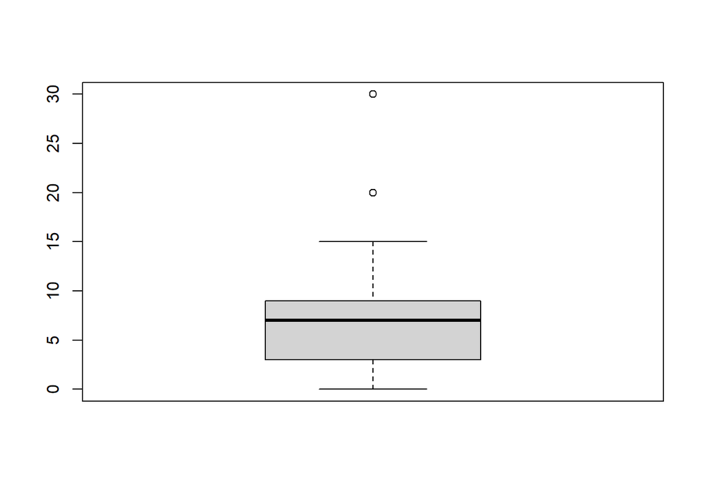

```r
boxplot(food_updated$Num_Dining)
```

I have displayed the numerical summary and a boxplot of the dining out data above, and frankly, I cannot think of a way to clean this further, as it seems to make sense to me.

8. Report your final number of observations after this cleaning.

```r
nrow(food_updated)
```

```
[1] 139
```

After cleaning, I am left with 139 observations.

## Problem 3 - Collatz conjecture

1. Write function nextCollatz that given a positive integer, computes the next number in its Collatz sequence.

```r
#' computes the next number in a number's Collatz sequence
#'
#' @param n a positive integer
#'
#' @returns a positive integer
#'
#' @examples
#' nextCollatz(5)
#' nextCollatz(16)
nextCollatz <- function(n) {
  # error checks
  if (!is.numeric(n)) {
    stop("n must be numeric")
  }
  if (n <= 0 || n %% 1 != 0) {
    stop("n must be a positive integer")
  }

  # if n is even
  if (n %% 2 == 0) {
    return(n/2)
  } else {
    return(3*n+1)
  }
}

nextCollatz(5)
```

```
[1] 16
```

```r
nextCollatz(16)
```

```
[1] 8
```

2. Create a function collatzSequence that returns the Collatz sequence for a given input.

```r
#' returns the Collatz sequence and its length
#'
#' @param n a positive integer
#'
#' @returns a list containing the vector of the entries in the Collatz sequence; and the length of the Collatz sequence
#'
#' @examples
#' collatzSequence(5)
#' collatzSequence(19)
collatzSequence <- function(n) {
  # error checks
  if (!is.numeric(n)) {
    stop("n must be numeric")
  }
  if (n <= 0 || n %% 1 != 0) {
    stop("n must be a positive integer")
  }

  # initiate sequence
  seq <- n
  while (n != 1) {
    n <- nextCollatz(n)
    seq <- c(seq, n)
  }

  return(list(seq, length(seq)))
}

collatzSequence(5)
```

```
[[1]]
[1]  5 16  8  4  2  1

[[2]]
[1] 6
```

```r
collatzSequence(19)
```

```
[[1]]
 [1] 19 58 29 88 44 22 11 34 17 52 26 13 40 20 10  5 16  8  4  2  1

[[2]]
[1] 21
```

3. Use these functions to find the shortest and longest Collatz sequence starting with values between 100 and 500, inclusive. In the case of ties, report the lowest starting value.

```r
values <- 100:500

collatz_lengths <- sapply(values, function(value) {
  collatzSequence(value)[[2]]
})


shortest_length <- min(collatz_lengths)
shortest_ind <- which.min(collatz_lengths)
longest_length <- max(collatz_lengths)
longest_ind <- which.max(collatz_lengths)

c(shortest_length, longest_length)
```

```
[1]   8 144
```

```r
c(values[shortest_ind], values[longest_ind])
```

```
[1] 128 327
```

The shortest Collatz sequence begins with the value of 128 and is of length 8. The longest Collatz sequence begins with the value of 327 and has a length of 144.